# epicrop

Adam H Sparks

2021-07-10

## Introduction to *epicrop*

*epicrop* provides an R package of the ‘EPIRICE’ model as described in Savary *et al.* 2012. Default values derived from the literature suitable for modelling unmanaged disease intensity of five rice diseases, bacterial blight (`predict_bacterial_blight()`); brown spot (`predict_brown_spot()`); leaf blast (`predict_leaf_blast()`); sheath blight (`predict_sheath_blight()`) and tungro (`predict_tungro()`) are provided. The model uses daily weather data to estimate disease intensity. A function, `get_wth()`, is provided to simplify downloading weather data from the [NASA POWER API](https://power.larc.nasa.gov) that are suitable for use in *epicrop*.

Using the package functions is designed to be straightforward for modelling rice disease risks, but flexible enough to accommodate other pathosystems using the `SEIR()` function. If you are interested in modelling other pathosystems, please refer to Savary *et al.* 2012 for the development of the parameters that were used for the rice diseases as derived from the existing literature and are implemented in the individual disease model functions.

### Getting started

Load the library.

```r
library("epicrop")
```

### Get weather data

The most simple way to use the model is to download weather data from NASA POWER using `get_wth()`, which provides the data in a format suitable for use in the model and is freely available. See the help file for `naspower::get_power()` for more details of this functionality and details on the data (Sparks 2018, Sparks 2020).

```r
# Fetch weather for year 2000 season at the IRRI Zeigler Experiment Station
wth <- get_wth(
  lonlat = c(121.25562, 14.6774),
  dates = c("2000-01-01", "2000-12-31")
)

wth
```

```
##        YYYYMMDD DOY  TEMP  RHUM  RAIN      LAT      LON
##   1: 2000-01-01   1 24.25 90.84  9.80 14.67741 121.2556
##   2: 2000-01-02   2 24.10 90.38  5.01 14.67741 121.2556
##   3: 2000-01-03   3 23.56 88.12  1.67 14.67741 121.2556
##   4: 2000-01-04   4 23.41 87.72  0.74 14.67741 121.2556
##   5: 2000-01-05   5 23.83 87.73  0.35 14.67741 121.2556
##  ---
## 362: 2000-12-27 362 24.27 92.93 26.32 14.67741 121.2556
## 363: 2000-12-28 363 24.39 92.33  6.67 14.67741 121.2556
## 364: 2000-12-29 364 24.39 91.57  7.19 14.67741 121.2556
## 365: 2000-12-30 365 24.96 87.13  2.97 14.67741 121.2556
## 366: 2000-12-31 366 24.22 87.21  3.04 14.67741 121.2556
```

### Predict bacterial blight

All of the `predict_()` family of functions work in exactly the same manner. You provide them with weather data and an emergence date, that falls within the weather data provided, and they will return a data frame of disease intensity over the season and other values associated with the model. See the help file for `SEIR()` for more on the values returned.

```r
# Predict bacterial blight intensity for the year 2000 wet season at IRRI
bb_wet <- predict_bacterial_blight(wth, emergence = "2000-07-01")
```

```r
summary(bb_wet)
```

```
##      simday        dates                sites            latent
##  Min.   :  0   Min.   :2000-06-30   Min.   : 100.0   Min.   :  0.000
##  1st Qu.: 30   1st Qu.:2000-07-30   1st Qu.: 946.3   1st Qu.:  0.732
##  Median : 60   Median :2000-08-29   Median :1689.5   Median : 14.778
##  Mean   : 60   Mean   :2000-08-29   Mean   :1552.6   Mean   : 56.623
##  3rd Qu.: 90   3rd Qu.:2000-09-28   3rd Qu.:2287.0   3rd Qu.:105.712
##  Max.   :120   Max.   :2000-10-28   Max.   :2581.1   Max.   :236.125
##    infectious        removed          senesced         rateinf
##  Min.   :  0.00   Min.   :  0.00   Min.   :   0.0   Min.   : 0.00
##  1st Qu.:  1.00   1st Qu.:  0.00   1st Qu.: 115.6   1st Qu.: 0.00
##  Median : 28.04   Median :  1.00   Median : 653.9   Median : 1.00
##  Mean   :255.97   Mean   : 55.43   Mean   : 822.4   Mean   :11.58
##  3rd Qu.:553.44   3rd Qu.: 30.45   3rd Qu.:1415.2   3rd Qu.:18.78
##  Max.   :921.59   Max.   :583.89   Max.   :2451.7   Max.   :55.92
##    rtransfer        rgrowth         rsenesced         diseased
##  Min.   : 0.00   Min.   : 9.688   Min.   : 1.000   Min.   :   0.000
##  1st Qu.: 0.00   1st Qu.:22.883   1st Qu.: 9.463   1st Qu.:   2.411
##  Median : 0.00   Median :32.120   Median :22.703   Median :  44.933
##  Mean   :11.20   Mean   :40.081   Mean   :20.753   Mean   : 368.017
##  3rd Qu.:18.78   3rd Qu.:56.958   3rd Qu.:25.936   3rd Qu.: 817.561
##  Max.   :55.92   Max.   :79.595   Max.   :60.740   Max.   :1391.817
##     severity         intensity            lat             lon
##  Min.   : 0.0000   Min.   : 0.0000   Min.   :14.68   Min.   :121.3
##  1st Qu.: 0.2265   1st Qu.: 0.2265   1st Qu.:14.68   1st Qu.:121.3
##  Median : 1.7708   Median : 1.7321   Median :14.68   Median :121.3
##  Mean   :13.5806   Mean   :12.3257   Mean   :14.68   Mean   :121.3
##  3rd Qu.:28.8129   3rd Qu.:28.0406   3rd Qu.:14.68   3rd Qu.:121.3
##  Max.   :56.2690   Max.   :43.9150   Max.   :14.68   Max.   :121.3
```

## Plotting using ggplot2

The data are in a wide format by default and need to be converted to long format for use in *ggplot2* if you wish to plot more than one variable at a time.

```r
library("ggplot2")
library("tidyr")
```

### Wet season sites

The model records the number of sites for each bin daily; this can be graphed as follows.

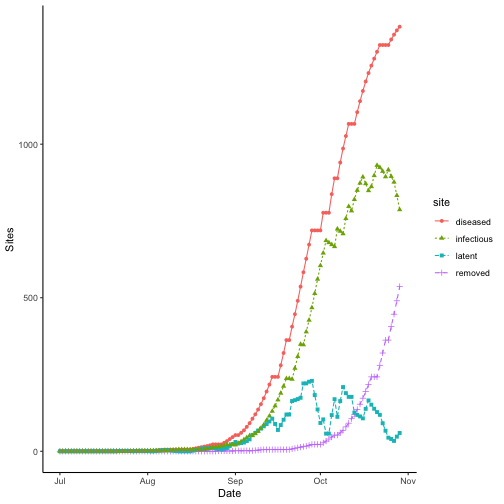

Site states over time for bacterial blight. Results for wet season year 2000 at IRRI Zeigler Experiment Station shown. Weather data used to run the model were obtained from the NASA Langley Research Center POWER Project funded through the NASA Earth Science Directorate Applied Science Program.

```r
dat <- pivot_longer(
  bb_wet,
  cols = c("diseased", "removed", "latent", "infectious"),
  names_to = "site",
  values_to = "value"
)

ggplot(data = dat,
       aes(
         x = dates,
         y = value,
         shape = site,
         linetype = site
       )) +
  labs(y = "Sites",
       x = "Date") +
  geom_line(aes(group = site, colour = site)) +
  geom_point(aes(colour = site)) +
  theme_classic()
```

### Wet season intensity

Plotting intensity over time does not require any data manipulation.

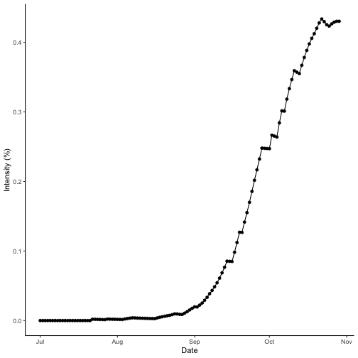

Wet season disease intensity over time for bacterial blight. Results for wet season year 2000 at IRRI Zeigler Experiment Station shown. Weather data used to run the model were obtained from the NASA Langley Research Center POWER Project funded through the NASA Earth Science Directorate Applied Science Program.

```r
ggplot(data = bb_wet,
       aes(x = dates,
           y = intensity)) +
  labs(y = "Intensity (%)",
       x = "Date") +
  geom_line() +
  geom_point() +
  theme_classic()
```

## Comparing epidemics

The most common way to compare disease epidemics in botanical epidemiology is to use the area under the disease progress curve (AUDPC) (Shaner and Finney 1977). This is easily calculated from the output of any of the `predict_()` family of functions or a custom `SEIR()` run using the *epifitter* package (Alves and Del Ponte 2020).

Load *epifitter* and simulate the disease intensity in the dry season starting in January to compare with the initial `bb_wet` results.

```r
library("epifitter")

bb_dry <- predict_bacterial_blight(wth = wth, emergence = "2000-01-05")
summary(bb_dry)
```

```
##      simday        dates                sites            latent
##  Min.   :  0   Min.   :2000-01-04   Min.   : 100.0   Min.   : 0.000
##  1st Qu.: 30   1st Qu.:2000-02-03   1st Qu.: 947.5   1st Qu.: 0.000
##  Median : 60   Median :2000-03-04   Median :2519.2   Median : 1.391
##  Mean   : 60   Mean   :2000-03-04   Mean   :1886.6   Mean   : 8.759
##  3rd Qu.: 90   3rd Qu.:2000-04-03   3rd Qu.:2647.7   3rd Qu.:11.435
##  Max.   :120   Max.   :2000-05-03   Max.   :2753.8   Max.   :83.088
##    infectious        removed         senesced         rateinf
##  Min.   :  0.00   Min.   : 0.00   Min.   :   0.0   Min.   : 0.0000
##  1st Qu.:  1.00   1st Qu.: 0.00   1st Qu.: 115.6   1st Qu.: 0.0000
##  Median : 12.05   Median : 1.00   Median : 655.2   Median : 0.0000
##  Mean   : 46.07   Mean   :13.62   Mean   : 839.7   Mean   : 1.7517
##  3rd Qu.: 86.26   3rd Qu.:13.05   3rd Qu.:1473.3   3rd Qu.: 0.4024
##  Max.   :170.82   Max.   :99.31   Max.   :2355.9   Max.   :30.9168
##    rtransfer          rgrowth         rsenesced         diseased
##  Min.   : 0.0000   Min.   : 9.688   Min.   : 1.000   Min.   :  0.000
##  1st Qu.: 0.0000   1st Qu.:28.843   1st Qu.: 9.475   1st Qu.:  1.402
##  Median : 0.0000   Median :34.324   Median :25.192   Median : 19.762
##  Mean   : 1.7517   Mean   :42.321   Mean   :19.797   Mean   : 68.446
##  3rd Qu.: 0.4024   3rd Qu.:57.313   3rd Qu.:27.274   3rd Qu.:128.874
##  Max.   :30.9168   Max.   :79.534   Max.   :40.265   Max.   :211.961
##     severity        intensity           lat             lon
##  Min.   :0.0000   Min.   :0.0000   Min.   :14.68   Min.   :121.3
##  1st Qu.:0.1904   1st Qu.:0.1904   1st Qu.:14.68   1st Qu.:121.3
##  Median :0.7784   Median :0.7393   Median :14.68   Median :121.3
##  Mean   :2.4597   Mean   :2.0041   Mean   :14.68   Mean   :121.3
##  3rd Qu.:4.5192   3rd Qu.:4.0802   3rd Qu.:14.68   3rd Qu.:121.3
##  Max.   :7.4870   Max.   :6.6557   Max.   :14.68   Max.   :121.3
```

### Dry season intensity

Check the disease progress curve for the dry season.

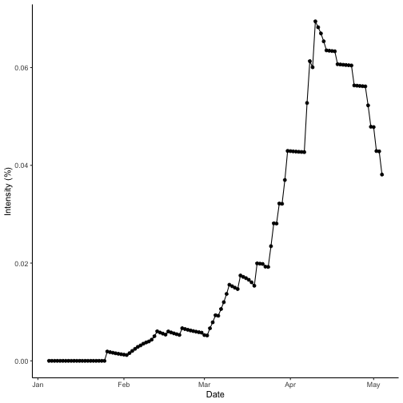

```r
ggplot(data = bb_dry,
       aes(x = dates,
           y = intensity)) +
  labs(y = "Intensity (%)",
       x = "Date") +
  geom_line() +
  geom_point() +
  theme_classic()
```

Calculate the AUDPC using the `AUDPC()` from *epifitter* for both seasons and compare.

```r
# Dry season
AUDPC(
  time = bb_dry$simday,
  y = bb_dry$intensity,
  y_proportion = FALSE,
  type = "relative"
)
```

```
## [1] 0.02003607
```

```r
# Wet season
AUDPC(
  time = bb_wet$simday,
  y = bb_wet$intensity,
  y_proportion = FALSE,
  type = "relative"
)
```

```
## [1] 0.1225029
```

The AUDPC of the wet season is greater than that of the dry season. Checking the data and referring to the curves, the wet season intensity reaches a peak value of 43.91% and the dry season tops out at 6.66%. So, this meets the expectations that the wet season AUDPC is higher than the dry season, which was predicted to have less disease intensity.

# References

Kaique dos S. Alves and Emerson M. Del Ponte (2020). epifitter: Analysis and Simulation of Plant Disease Progress Curves. R package version 0.2.0. URL: https://CRAN.R-project.org/package=epifitter.

Serge Savary, Andrew Nelson, Laetitia Willocquet, Ireneo Pangga and Jorrel Aunario. Modeling and mapping potential epidemics of rice diseases globally. *Crop Protection*, Volume 34, 2012, Pages 6-17, ISSN 0261-2194 DOI: 10.1016/j.cropro.2011.11.009.

Gregory Shaner and R. E. Finney. "The effect of nitrogen fertilization on the expression of slow-mildewing resistance in Knox wheat. *Phytopathology* Volume 67.8, 1977, Pages 1051-1056.

Adam Sparks (2018). nasapower: A NASA POWER Global Meteorology, Surface Solar Energy and Climatology Data Client for R. Journal of Open Source Software, 3(30), 1035, DOI: 10.21105/joss.01035.

Adam Sparks (2020). *nasapower: NASA-POWER Data from R*. R package version 3.0.1, URL: https://CRAN.R-project.org/package=nasapower.